# Machine Learning Project

Michael Scully

January 29, 2016

# Getting Started

First, I“ll load the testing and training sets provided for the assignment

```r
library(caret)
training = read.csv("~/Downloads/pml-training.csv")
testing = read.csv("~/Downloads/pml-testing.csv")
```

Since the `testing` data will be used to evaluate performance of the analysis, I open to see what data will be provided in order to create a prediction. The first 7 columns are descriptive rather than quantifications, so they will not help the prediction and can be removed. All columns that are all `NA` in the `testing` set can also be removed from the training data, since these fields add no value in the testing data set. Removing these extra columns will improve performance times.

```r
# What are the column names in testing where all values are NA?
colnames <- names(testing)[colSums(is.na(testing)) == 0]

# Remove 'problem_id' from end of list since this column does not exist in training set (and it is descriptive)
colnames <- colnames[1:59]

# Add in outcome column 'classe'
colnames <- c(colnames, 'classe')

# Subset to just these same columns in training set
training.refined <- training[,colnames]

# Further, remove descriptive fields from training set (the first 7 columns) as they add no predictive value
training.refined <- training.refined[,8:60]
```

Now that our training data is thinned out from variables that will not be useful for this assignment, I will perform `cv` (K-folds cross validation) and use the `random forest` training method. From the lectures, random forests (rf) tend to be well suited for prediction where there are a large number of inputs with unknown interactions between them.

```r
# for reproducability
set.seed(1234)

# create train control settings  with cross validation (5 repeats instead of default 25 to decrease processing time)
control <- trainControl(method="cv", number=5, repeats=5, savePredictions = TRUE)

# train the model using random forest method (with K-fold cross validation defined in control)
modFit <- train(classe ~ ., method="rf", data=training.refined, trControl = control)
```

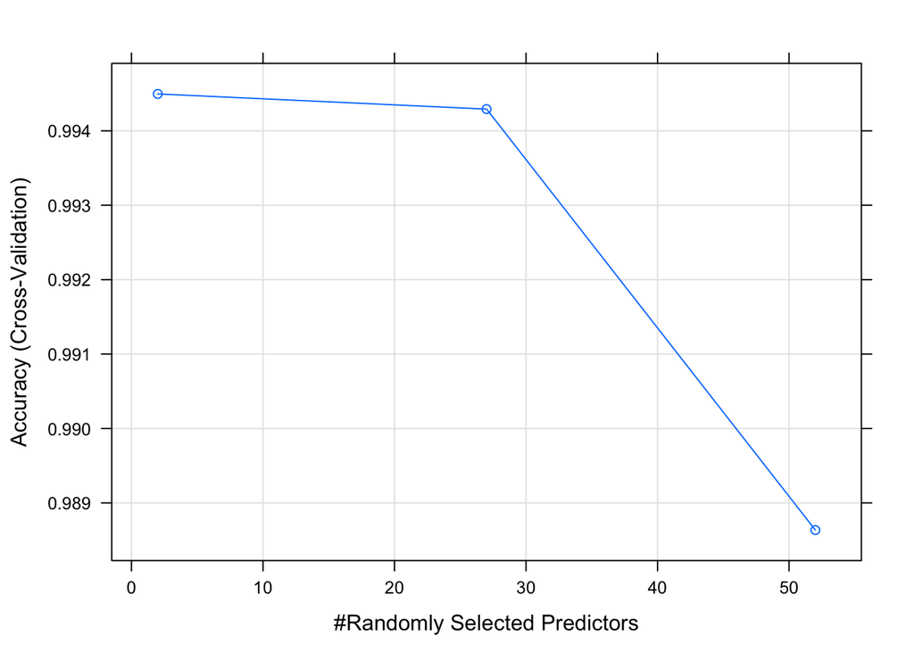

```r
# view cv accuracy (indication of expected out-of-sample error)
plot(modFit)  #
```

```r
getTrainPerf(modFit)
```

```
##   TrainAccuracy TrainKappa method
## 1     0.9944958  0.9930371     rf
```

The best model has an accuracy of 0.9944958.

The OOB estimate of error rate is can be seen in the the finalModel output below:

```r
modFit$finalModel
```

```
##
## Call:
##  randomForest(x = x, y = y, mtry = param$mtry)
##                Type of random forest: classification
##                      Number of trees: 500
## No. of variables tried at each split: 2
##
##         OOB estimate of  error rate: 0.42%
## Confusion matrix:
##      A    B    C    D    E  class.error
## A 5578    2    0    0    0 0.0003584229
## B   14 3777    6    0    0 0.0052673163
## C    0   15 3405    2    0 0.0049678551
## D    0    0   39 3176    1 0.0124378109
## E    0    0    0    4 3603 0.0011089548
```

Now that we have a good model, let’s apply it to the testing data and return prediction results.

```r
prediction <- predict(modFit, newdata = testing)
prediction
```

```
##  [1] B A B A A E D B A A B C B A E E A B B B
## Levels: A B C D E
```